# Discrete Random Variables

## 1 Discrete Random Variable

**Definition:** Let $\Omega$ be a sample space. A real-valued function $W$: $\Omega \rightarrow \mathcal{R}$ is called a **random variable**.

This definition sounds daunting, but we use it everyday.

*Example:* In an academic transcript, each letter grade in $\Omega = \{ a, b, c, d, f \}$ is mapped to a numeric value 4, 3, 2, 1, and 0, respectively. This process can be expressed as follows: $W(a) = 4$, $W(b) = 3$, $W(c) = 2$, $W(d) = 1$, and $W(f) = 0$. By the aforementioned definition,

- $W$ is a random variable, and
- $\mathcal{S}_W = \{ 0, 1, 2, 3, 4 \}$, the set of possible values of $W$, is called the **support** of $W$

More specifically, $W$ is a **discrete random variable** as its support $\mathcal{S}_W$ is countable.

*Example:* At the end of a soccer match, the sample space is $\Omega = \{ win, tie, loss \}$ for each team. In a professional soccer league, each game outcome is transformed to a numeric score as follows: $X(win) = 3$, $X(tie) = 1$, and $X(loss) = 0$. In this case,

- $X$ is a discrete random variable, and

$\mathcal{S}_X = \{ 0, 1, 3 \}$ is the support of $X$.

Each team in a league plays a large number of matches, and this random variable helps ranking teams at the end of the league (e.g., 10 wins, 5 ties, and 5 losses are equivalent to 35 points).

Sometimes, an experiment returns a numeric outcome.

*Example:* Let $Y$ be the total number of goals a team scored in a match. In this case,

- $Y$ is a discrete random variable, and
- its support is $\mathcal{S}_Y = \{ 0, 1, 2, 3, \dots \}$.

Let $Z$ be the outcome of tossing a 6-sided die. In this case, $Z$ is also a random variable, and its support is $\mathcal{S}_Z = \{ 1, 2, 3, 4, 5, 6 \}$.

## 2 Probability Mass Function

**Definition:** Let $X$ be a discrete random variable and $\mathcal{S}_X$ be its support. We say $f_X$: $\mathcal{S}_X \rightarrow \mathcal{R}$ is a **probability mass function** (or **PMF**) if it satisfies the following two conditions:

1. $f_X(x) \ge 0$ for any $x \in \mathcal{S}_X$
2. $\sum_{x \in \mathcal{S}_X} f_X(x) = 1$

We already have seen this kind of definition in a previous lecture. The PMF is a probability model for a discrete random variable.

*Example:* Let $X$ be the points earned per match (3 for a win, 1 for a tie, and 0 for a loss). Given the support $\mathcal{S}_X = \{ 0, 1, 3 \}$, assume the following PMF:

$$f_X(0) = 0.2 \, , \,\,\, f_X(1) = 0.3 \, , \,\,\, f_X(3) = 0.5 \, .$$

## 3 Expectation

**Definition:** Let $X$ be a random variable, $\mathcal{S}_X$ be the support of $X$, and $f_X$ be the PMF of $X$. The **expectation** of $X$ is defined as

$$E(X) = \sum_{x \in \mathcal{S}_X} x \cdot f_X(x) \, .$$

The expectation of $X$ is also called the **average**, **mean**, or **expected value** of $X$.

**Note:** In words, the expectation of $X$ is the weighted average of all possible values of $X$ where each possible value of $X$ is weighted by its probability.

*Example:* In a previous example, we let $X$ be the points a soccer team earned per match, and assumed $f_X(0) = 0.2$, $f_X(1) = 0.3$, and $f_X(3) = 0.5$. According to the definition, the expectation of $X$ (i.e., the expected points per match) is

**NoteAnswer**

$$E(X) = 0 \cdot 0.2 + 1 \cdot 0.3 + 3 \cdot 0.5 = 1.8 \, .$$

*Example:* Assume we have a new team where $f_X(0) = 0.5$, $f_X(1) = 0.1$, and $f_X(3) = 0.4$. In this case, the expected points per game is

**NoteAnswer**

$$E(X) = 0 \cdot 0.5 + 1 \cdot 0.1 + 3 \cdot 0.4 = 1.3 \, .$$

Which team is is better on average when it comes to points per game?

**NoteAnswer**

The former team is better than the latter team by 0.5 points on average.

*Example:* In the example of tossing a six-sided die, we assumed $f_Z(z) = \frac{1}{6}$ for $z = 1, 2, \dots, 6$. By the definition, the expected outcome is

**NoteAnswer**

$$\begin{aligned}
E(Z) & = \sum_{z = 1}^6 s \cdot f_Z(z) \\
& = \sum_{z = 1}^6 z \cdot \frac{1}{6} \\
& = \frac{1}{6} \cdot \sum_{z = 1}^6 z \\
& = \frac{1}{6} \cdot (1 + 2 + \dots + 6) \\
& = 3.5 \, .
\end{aligned}$$

## 4 Variance

In some sense, the expectation characterizes a probability model in terms of the central tendency. We can also characterize a probability model in terms of variability or dispersion from the expectation.

**Definition:** Let $X$ be a random variable, $\mathcal{S}_X$ be the support of $X$, and $f_X$ be the PMF of $X$. Let $E(X)$ be the expectation of $X$. The **variance** of $X$ is defined as

$$V(X) = \sum_{x \in \mathcal{S}_X} [x - E(X)]^2 \cdot f_X(x) \, .$$

In words, the variance is the expected square distance of $X$ from $E(X)$, and it quantifies the variability of the random variable $X$ from its own average $E(X)$.

*Example:* In the soccer example, given the PMF $f_X(0) = 0.2$, $f_X(1) = 0.3$, and $f_X(3) = 0.5$, we calculated the expectation, $E(X) = 1.8$, and we can calculate that the variance as follows:

**Note**

$$V(X) = (0 - 1.8)^2 \cdot 0.2 + (1 - 1.8)^2 \cdot 0.3 + (3 - 1.8)^2 \cdot 0.5 = 1.56 \, .$$

Given the other PMF $f_X(0) = 0.5$, $f_X(1) = 0.1$, and $f_X(3) = 0.4$. we calculated that the expectation is $E(X) = 1.3$, and we can calculate that the variance is $V(X) = 2.01$. The latter team has the lower expected points per game, and it has a higher variance than the former team.

**Definition:** The **standard deviation** of $X$ is defined as $\sqrt{ V(X) }$, the square root of the variance of $X$.

**Example:** In the example of tossing a six-sided die, we assumed $f_Z(z) = \frac{1}{6}$ for $z = 1, 2, \dots, 6$, and we calculated $E(Z) = 3.5$. By the definition of variance,

**Note**

$$\begin{aligned}
V(Z) & = \sum_{z = 1}^6 [z - E(Z)]^2 \cdot f_Z(z) \\
& = \sum_{s = 1}^6 [z - 3.5]^2 \cdot \frac{1}{6} \\
& = \frac{1}{6} \cdot \sum_{z = 1}^6 [z - 3.5]^2 \\
& = \frac{1}{6} \cdot [ (1 - 3.5)^2 + (2-3.5)^2 + \dots + (6 - 3.5)^2 ] \\
& = 2.9167 \, ,
\end{aligned}$$

and the standard deviation is $\sqrt{V(Z)} = 1.7078$.

## 5 Bernoulli Random Variable

When an experiment has binary outcomes, say 0 and 1, it is called a **Bernoulli experiment**. A traditional example is a coin toss. Let $X$ be the outcome of a coin toss where $X = 1$ represents an outcome of head and $X = 0$ represents an outcome of tail, so the support is $\mathcal{S}_X = \{ 0, 1 \}$. In this case, we say $X$ is a **Bernoulli random variable**, and its PMF is generically expressed by $f_X(1) = \theta$ and $f_X(0) = 1 - \theta$ where $\theta$ is a fixed number between 0 and 1. In this case, $\theta$ implies the probability of head, and $1 - \theta$ implies the probability of tail.

In this generic expression, the expectation of $X$ is

**Note**

$$E(X) = 0 \cdot (1-\theta) + 1 \cdot \theta = \theta \, ,$$

and the variance of $X$ is

**Note**

$$\begin{aligned}
V(X) & = (0 - \theta)^2 \cdot (1-\theta) + (1 - \theta)^2 \cdot \theta \\
& = \theta^2 \cdot (1-\theta) + (1-\theta)^2 \cdot \theta \\
& = \theta \cdot (1-\theta) \cdot [\theta + (1-\theta)] \\
& = \theta \cdot (1-\theta) \, .
\end{aligned}$$

*Example* If we assume that the probability of head is $\theta = 0.51$ for a Bernoulli random variable $X$, find the expectation and variance.

**Note**

$E(X) = 0.51$ and a variance of $V(X) = 0.51 \cdot (1-0.51) = 0.2499$.

## 6 Binomial Random Variable

Let $X$ be a Bernoulli random variable. Let $X = 1$ be a success and $X = 0$ be a failure. Let $\theta$ be the probability of $X = 1$. Assume the Bernoulli experiment is repeated $n$ times under the same condition. More specifically, assume the following:

1. $n$ is fixed.
2. $\theta$ is constant.
3. Outcomes of $n$ trials are independent.

Let $Y$ be the number of successes in $n$ trials. In this case, $Y$ is called the **binomial random variable**, the support is $\mathcal{S}_Y = \{ 0, 1, 2, \dots, n \}$, and the PMF of $Y$ is given by

$$f_Y(y) = \frac{n!}{y! (n-y)!} \, \theta^y \, (1-\theta)^{n-y} \, , \,\,\, y = 0, 1, 2, \dots, n \, .$$

In this case, we simply write $Y \sim \mathrm{Bino}(n, \theta)$.

*Example:* Suppose we toss a coin three times where the probability of a head is $\theta = 0.9$ for each trial. Let $Y$ be the number of heads out of $n = 3$. Assuming $Y \sim \mathrm{Bino}(3, 0.9)$, which implies the three assumptions are satisfied, the support is $\mathcal{S}_Y = \{ 0, 1, 2, 3 \}$, and the PMF is as follows:

**Note**

$$\begin{aligned}
f_Y(0) & = \frac{3!}{0! \, 3!} \, (0.9)^0 \, (0.1)^{3} = 0.001 \, , \\
f_Y(1) & = \frac{3!}{1! \, 2!} \, (0.9)^1 \, (0.1)^{2} = 0.027 \, , \\
f_Y(2) & = \frac{3!}{2! \, 1!} \, (0.9)^2 \, (0.1)^{1} = 0.243 \, , \\
f_Y(3) & = \frac{3!}{3! \, 0!} \, (0.9)^3 \, (0.1)^{0} = 0.729 \, .
\end{aligned}$$

We can calculate $f_Y(y)$ by $\texttt{dbinom}(y, n, \theta)$ in R.

According to the definition, the expected number of heads out of three trials is

**Note**

$$E(Y) = 0 \cdot 0.001 + 1 \cdot 0.027 + 2 \cdot 0.243 + 3 \cdot 0.729 = 2.7 \, ,$$

and the variance is

**Note**

$$\begin{aligned}
V(Y) & = (0 - 2.7)^2 \cdot 0.001 + (1 - 2.7)^2 \cdot 0.027 \\
& \,\,\, + (2 - 2.7)^2 \cdot 0.243 + (3 - 2.7)^2 \cdot 0.729 \\
& = 0.27 \, .
\end{aligned}$$

**Note:** If $Y \sim \mathrm{Bino}(n, \theta)$, then

- $E(Y) = n \cdot \theta$ and
- $V(Y) = n \cdot \theta(1-\theta)$.

In the previous example, the expectation and variance can be calculated as follows:

**Note**

$$\begin{aligned}
E(Y) & = 3(0.9) = 2.7 \, , \\
V(Y) & = 3(0.9)(1-0.9) = 0.27 \, .
\end{aligned}$$

*Example:* Suppose a test consists of ten multiple-choice questions, and each question has one correct answer out of four choices. Seven or more correct answers are needed to pass the test. What is the probability of passing the test if we randomly guess each answer?

Let $Y$ be the number of correct answers.

$$f_Y(y) = \frac{10!}{y! \, (10-y)!} \, \theta^y (1-\theta)^{10-y} \, , \,\,\, y = 0, 1, 2, \dots, 10 \, .$$

We can calculate that the probability of passing the test ($Y = 7$ or more) is

**Note**

$$\begin{aligned}
P(Y \ge 7) & = f_Y(7) + f_Y(8) + f_Y(9) + f_Y(10) \\
& = 0.003090 + 0.000386 + 0.000029 + 0.000001 \\
& = 0.0035 \, .
\end{aligned}$$

## 7 Wrap-Up

In your groups work on the following problems. You can check your answers below. All calculations (numeric answers) must be rounded to four decimals (e.g., 0.6667 instead of 2/3, 0.5 or 0.5000 instead of 1/2) unless specified. Be ready to show your work on the board.

#### 7.0.1 Problem 1

Let $X$ be a discrete random variable. Fill in the blanks.

1. The set of all possible values of $X$ is called the [s…], and it is denoted by $\mathcal{S}_X$.

**TipAnswer**

support

2. The [p… m… f…] is a function which receives a possible value of $X$ and returns its probability.

**TipAnswer**

probability mass function

3. Let $f_X$ be the PMF of $X$. $f_X(x) = p$ is interpreted as the [p…] of $X = x$.

**TipAnswer**

probability

4. Assume $\mathcal{S}_X = \{ 1, 2, 3 \}$. The sum of $f_X(1)$, $f_X(2)$, and $f_X(3)$ must equal to [o…].

**TipAnswer**

one

5. The [e…] of $X$ is the weighted average of all possible values of $X$ where each possible value is weighted by its probability.

**TipAnswer**

expectation

6. The [v…] of $X$ is the expected square distance of $X$ from its average.

**TipAnswer**

variance

7. The square root of the variance is called the [s… d…].

**TipAnswer**

standard deviation

8. When a random variable $X$ can be either $X = 1$ or $X = 0$, it is called the [B…] random variable.

**TipAnswer**

Bernoulli

#### 7.0.2 Problem 2

Let $X$ be a random variable such that $\mathcal{S}_X = \{ -1, 0, 1 \}$ and $f_X(x) = 0.5 x^2$ for $x = -1, 0, 1$. Calculate the following.

1. $f_X(-1) + f_X(0) + f_X(1)$

**TipAnswer**

1

2. $E(X)$

**TipAnswer**

0

3. $V(X)$

**TipAnswer**

1

#### 7.0.3 Problem 3

Let $X$ be a Bernoulli random variable such that the probability of $X = 1$ is 0.7. Calculate the following.

1. $f_X(0)$

**TipAnswer**

0.3

2. $E(X)$

**TipAnswer**

0.7

3. $V(X)$

**TipAnswer**

0.21

#### 7.0.4 Problem 4

Suppose we toss a coin four times. Assume the probability of head is 0.5 for each toss, and all tosses are independent. Let $T$ be the number of heads out of four trials.

1. Fill in the blank: $T$ is called the [B…] random variable, and we write it as $T \sim \mathrm{Bino}(n, \theta)$ with $n = 4$ and $\theta = 0.5$.

**TipAnswer**

Binomial

2. Calculate $f_T(2)$, the probability of exactly two heads.

**TipAnswer**

0.375

3. Calculate $P(T \ge 2)$, the probability of two or more heads.

**TipAnswer**

0.6875

4. Calculate $E(T)$.

**TipAnswer**

2

5. Calculate $V(T)$.

**TipAnswer**

1

#### 7.0.5 Problem 5

Suppose we toss a coin 200 times. Assume the probability of head is 0.7 for each toss, and all tosses are independent. Calculate the probability of 160 or more heads.

**TipAnswer**

0.0009

## 8 Assignment

Check your answer by inputting them below their respective question. All calculations (numeric answers) must be rounded to four decimals (e.g., 0.6667 instead of 2/3, 0.5 or 0.5000 instead of 1/2) unless specified.

Though you are checking the numeric answers here, you should make sure your written work is complete and your mathematical notation is correct as both will be graded on the homework quiz.

#### 8.0.1 Problem 1

Suppose we toss a 12-sided die. Assume all faces are equally likely to occur. Let $X$ be the outcome where $\mathcal{S}_X = \{ 1, 2, \dots, 12 \}$. Calculate the following.

1. $\sum_{x = 1}^{12} f_X(x)$

**TipAnswer**

1

2. $f_X(1)$

**TipAnswer**

0.0833

3. $P(X \ge 10)$, the probability of any double-digit outcome

**TipAnswer**

0.25

4. $E(X)$

**TipAnswer**

6.5

5. $V(X)$

**TipAnswer**

11.9167

#### 8.0.2 Problem 2

Let $T$ be a random variable where $\mathcal{S}_T = \{ 1, 2, 3, 4 \}$. Assume the PMF is given by

$$f_T(t) = c \cdot t \, , \,\,\, t = 1, 2, 3, 4$$

where $c > 0$ is some constant. Calculate the following.

1. $c$

**TipAnswer**

0.1

2. $f_T(4)$

**TipAnswer**

0.4

3. $E(T)$

**TipAnswer**

3

4. $V(T)$

**TipAnswer**

1

#### 8.0.3 Problem 3

Suppose we toss a pair of 6-sided dice. Assume all 36 paired outcomes are equally likely. Let $X$ be the outcome of the first die, and $Y$ be the outcome of the second die. Let $D = | X - Y |$ which is a random variable. Let $\mathcal{S}_D$ be the support of $D$, and let $f_D$ be the PMF of $D$.

1. How many possible outcomes are in $\mathcal{S}_D$.

**TipAnswer**

6

2. Calculate $f_D(3)$.

**TipAnswer**

0.1667

3. Which outcome in $\mathcal{S}_D$ is the most likely outcome?

**TipAnswer**

1

4. Calculate $E(D)$.

**TipAnswer**

1.9444

5. Calculate the standard deviation of $D$.

**TipAnswer**

1.4326

#### 8.0.4 Problem 4

Let $X$, $Y$, and $Z$ be random variables with the common support $\mathcal{S}_X = \mathcal{S}_Y = \mathcal{S}_Z =\{ 0, 1, 2, 3, 4 \}$. Their PMFs are graphically shown below.

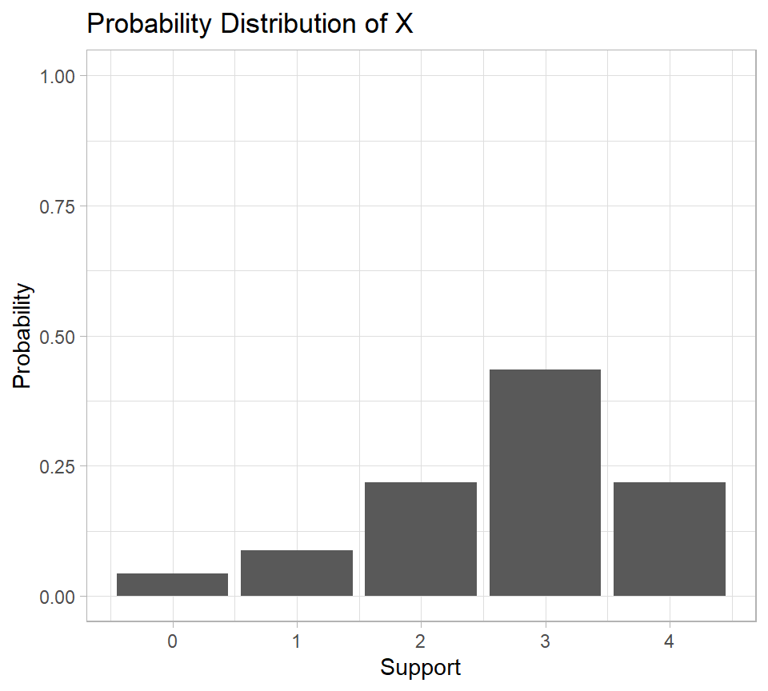

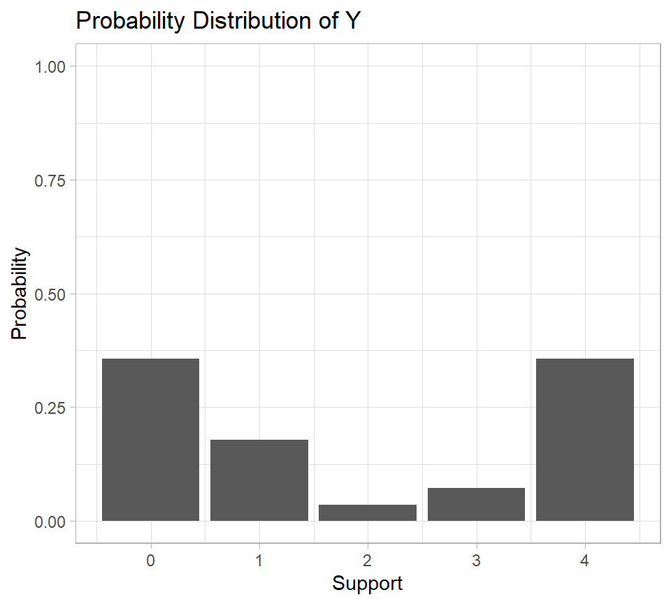

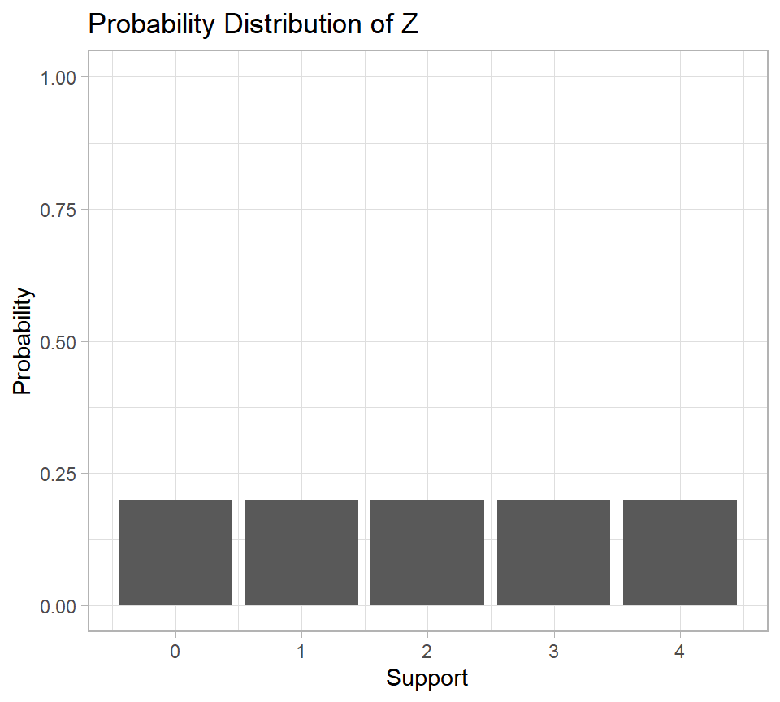

1. Multiple-choice: Which random variable has the largest expectation?

X  
Y  
Z  
X, Y, and Z have the same expectation.

2. Multiple-choice: Which random variable has the largest variance?

X  
Y  
Z  
X, Y, and Z have the same variance.

3. Multiple-choice: Which random variable has the largest standard deviation?

X  
Y  
Z  
X, Y, and Z have the same standard deviation.

#### 8.0.5 Problem 5

Suppose there are 12 multiple-choice questions in an exam. There are four choices per question, there is only one correct answer per question, and you earn 1 point per correct answer and 0 points per incorrect answer. The passing score is 75% or higher. Using the binomial probability model, calculate the probability of passing the exam under the given assumption. You may use the $\texttt{dbinom}$ function in R.

1. You are not prepared at all, so you randomly guess.

**TipAnswer**

0.0004

2. You are able to eliminate one incorrect answer, then randomly guess.

**TipAnswer**

0.0039

3. You are able to eliminate two incorrect answers, then randomly guess.

**TipAnswer**

0.073

4. You are well prepared to choose a correct answer with a probability 0.9.

**TipAnswer**

0.9744

#### 8.0.6 Problem 6

Hotel ratings by customers

| Rating | 1 | 2 | 3 | 4 | 5 |
| --- | --- | --- | --- | --- | --- |
| Hotel 1 | 20% | 10% | 10% | 20% | 40% |
| Hotel 2 | 10% | 20% | 40% | 20% | 10% |

Let $f_X$ and $f_Y$ represent the probability models for the ratings of Hotel 1 and 2, respectively.

1. Draw $f_X$ and $f_Y$.
2. Calculate $E(X)$ and $E(Y)$. Which hotel provides better experiences on average?

**TipAnswer**

$E(X) = 3.5$  
$E(Y) = 3$

3. Calculate $V(X)$ and $V(Y)$. Which hotel provides more predictable (less uncertain) experiences for customers?

**TipAnswer**

$V(X) = 2.45$  
$V(Y) = 1.2$

4. Let $f_Z$ represent the probability model for the ratings of Hotel 3. Assume $f_Z(1) = 0.5$, $f_Z(2) = f_Z(3) = f_Z(4) = 0$, and $f_Z(5) = 0.5$. Draw $f_Z$, and calculate $E(Z)$ and $V(Z)$.

**TipAnswer**

$E(Z) = 3$  
$V(Z) = 4$

5. Why is it important to consider both average and variance when we describe a probability model?

**TipAnswer**

Both average and variance are numeric descriptions of a probability distribution. The average measures the center of a probability distribution, and the variance measures the variability of an outcome around the center. It is possible that two probability distributions have the same average with different variances like the ratings of Hotels 2 and 3. Even though the two hotels have the same average rating of 3, visitors have extreme experiences in Hotel 3 (which results in a variance of 4), whereas visitors have relatively consistent experiences (near the average) in Hotel 2 (which results in a variance of 1.2).